# AR(1) Inference

Lecture 12

February 20, 2026

# Review

## Time Series

**Dependence**: History or sequencing of the data matters

$$p(y_t) = f(y_1, \ldots, y_{t-1})$$

Serial dependence captured by **autocorrelation**:

$$\varsigma(i) = \rho(y_t, y_{t-i}) = \frac{\text{Cov}[y_t, y_{t-i}]}{\mathbb{V}[y_t]}$$

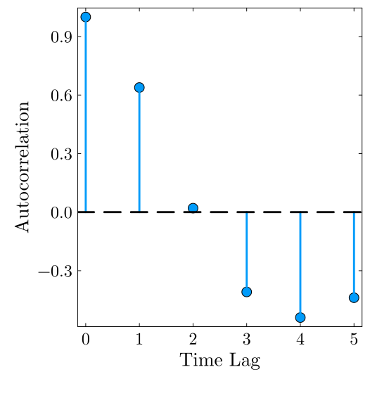

Figure 1: Autocorrelation for the Lynx data.

## Autocorrelation vs. Partial Autocorrelation

- **Autocorrelation at lag $i$**: $\varsigma(i) = \text{Cor}(y_t, y_{t-i})$
- **Partial Autocorrelation**: Autocorrelation from lag $i$ **when accounting for intermediate lags**.

Use partial autocorrelation to diagnose autoregressive orders.

## AR(1) Models

AR(1):

$$\begin{align*}
y_t &= \alpha + \rho y_{t-1} + \varepsilon_t \\
\varepsilon &\sim \mathcal{D}(\theta) \\
y_0 &\sim \mathcal{G}(\psi)
\end{align*}$$

$\mathbb{E}[\varepsilon] = 0$, $\text{cor}(\varepsilon_i, \varepsilon_j) = 0$, $\text{cor}(\varepsilon_i, y_0) = 0$

## Stationary Processes

A time series $y_t$ is **weakly stationary** if $\mathbb{E}[Y_t] = \mathbb{E}[Y_{t+1}]$ and $\text{Cov}(Y_1, Y_k) = \text{Cov}(Y_t, Y_{t+k-1})$.

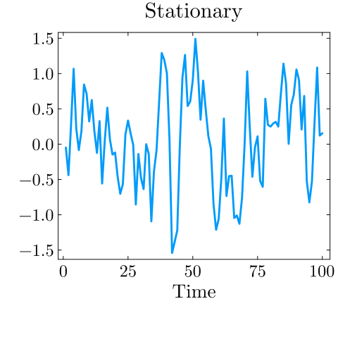

(a) Stationary vs. Non-stationary time series

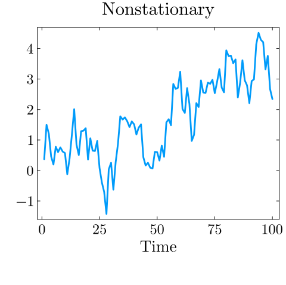

(b)

Figure 2

# AR(1) Inference

## AR(1) Variance

The **conditional variance** $\mathbb{V}[y_t | y_{t-1}] = \sigma^2$.

**Unconditional variance** for stationary $\mathbb{V}[y_t]$:

$$\begin{align*}
\mathbb{V}[y_t] &= \rho^2 \mathbb{V}[y_{t-1}] + \mathbb{V}[\varepsilon] \\
&= \rho^2 \mathbb{V}[y_t] + \sigma^2 \\
&= \frac{\sigma^2}{1 - \rho^2}.
\end{align*}$$

## AR(1) and Stationarity

Need $\mathbb{E}[Y_t] = \mathbb{E}[Y_{t-1}]$ and $\mathbb{V}[Y_t] = \mathbb{V}[Y_{t-1}]$. If we want this to hold:

$$\begin{aligned}
\mathbb{E}[Y_t] &= \mathbb{E}[\alpha + \rho Y_{t-1} + \varepsilon_t] \\
&= \alpha + \mathbb{E}[Y_{t-1}] + \cancel{\mathbb{E}[\varepsilon_t]} \\[0.75em]
\Rightarrow \mathbb{E}[Y_t] &= \alpha + \rho \mathbb{E}[Y_t] \\
&= \frac{\alpha}{1-\rho}.
\end{aligned}$$

## AR(1) and Stationarity

Now for the variance:

$$\begin{aligned}
\mathbb{V}[Y_t] = \mathbb{V}[\alpha + \rho Y_{t-1} + \varepsilon_t] \\
&= \rho^2 \mathbb{V}[Y_{t-1}] + \cancel{2\text{Cov}(Y_{t-1}, \varepsilon_t)} + \mathbb{V}[\varepsilon_t] \\[0.75em]
\Rightarrow \mathbb{V}[Y_t] &= \rho^2 \mathbb{V}[Y_t] + \sigma^2 \\
&= \frac{\sigma^2}{1 - \rho^2}.
\end{aligned}$$

Thus the AR(1) is stationary if and only if $|\rho| < 1$.

## Implication of Stationarity

Think about deterministic version (set $\alpha = 0$ to simplify):

$$y_t = \rho y_{t-1} = \rho^t y_0$$

**Stationarity**:
$$|\rho| < 1 \Rightarrow \lim_{t \to \infty} \rho^t = 0.$$

Stationary AR(1)s will decay to 0 on average and non-stationary will diverge to $\pm \infty$.

## Effect of Noise

Innovations/noise continually perturb away from this long-term deterministic path.

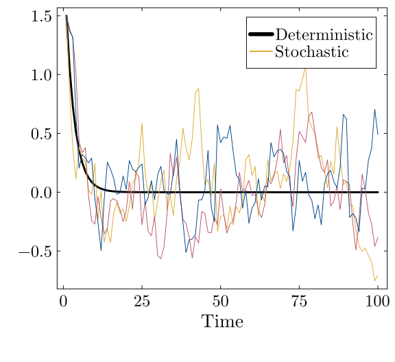

Figure 3: Determinitic vs. Stochastic AR(1)

```julia
ρ = 0.7
σ = 0.2
ar_var = sqrt(σ^2 / (1 - ρ^2))
T = 100
ts_det = zeros(T)
n = 3
ts_stoch = zeros(T, n)
t0 = 1.5
for i = 1:T
    if i == 1
        ts_det[i] = t0
        ts_stoch[i, :] .= t0
    else
        ts_det[i] = ρ * ts_det[i-1]
        ts_stoch[i, :] = ρ * ts_stoch[i-1, :] .+ rand(Normal(0, σ), n)
    end
end

p = plot(1:T, ts_det, label="Deterministic", xlabel="Time", linewidth=3, color=:black, size=(600, 550))
cols = ["#DDAA33", "#BB5566", "#004488"]
for i = 1:n
    label = i == 1 ? "Stochastic" : false
    plot!(p, 1:T, ts_stoch[:, i], linewidth=1, color=cols[i], label=label)
end
p
```

## AR(1) Joint Distribution

Assume stationarity and zero-mean process ($\alpha = 0$).

Need to know $\text{Cov}[y_t, y_{t-h}]$ for arbitrary $h$.

$$\begin{align*}
\text{Cov}[y_t, y_{t-h}] &= \text{Cov}[\rho^h y_{t-h}, y_{t-h}] \\
&= \rho^h \text{Cov}[y_{t-h}, y_{t-h}] \\
&= \rho^h \frac{\sigma^2}{1-\rho^2}
\end{align*}$$

## AR(1) Joint Distribution

$$\begin{align*}
\mathbf{y} &\sim \mathcal{N}(\mathbf{\mu}, \Sigma) \\
\Sigma &= \frac{\sigma^2}{1 - \rho^2} \begin{pmatrix}1 & \rho & \ldots & \rho^{T-1} \\ \rho & 1 & \ldots & \rho^{T-2} \\ \vdots & \vdots & \ddots & \vdots \\ \rho^{T-1} & \rho^{T-2} & \ldots & 1\end{pmatrix}
\end{align*}$$

where $\mu = \frac{\alpha}{1 - \rho}$.

## Alternatively..

An “easier approach” (often more numerically stable) is to **whiten** the series sample/compute likelihoods in sequence.

Calculate whitened residuals
$$r_t = y_t - \left(\alpha + \rho * y_{t-1}\right).$$

$$\begin{align*}
y_0 & \sim N\left(\frac{\alpha}{1 - \rho}, \frac{\sigma^2}{1 - \rho^2}\right) \\
r_t &\sim N(0, \sigma^2)
\end{align*}$$

## Code for AR(1) model

```julia
function ar1_loglik_whitened(θ, dat)
    # might need to include mean or trend parameters as well
    # subtract trend from data to make this mean-zero in this case
    α, ρ, σ = θ
    T = length(dat)
    ll = 0 # initialize log-likelihood counter
    for i = 1:T
        if i == 1
            ll += logpdf(Normal(α / (1 - ρ), sqrt(σ^2 / (1 - ρ^2))), dat[i])
        else
            r = dat[i] - (α + ρ * dat[i-1])
            ll += logpdf(Normal(0, σ), r)
        end
    end
    return ll
end

function ar1_loglik_joint(θ, dat)
    # might need to include mean or trend parameters as well
    # subtract trend from data to make this mean-zero in this case
    α, ρ, σ = θ
    T = length(dat)
    # compute all of the pairwise lags
    # this is an "outer product"; syntax will differ wildly by language
    H = abs.((1:T) .- (1:T)')
    P = ρ.^H # exponentiate ρ by each lag
    Σ = σ^2 / (1 - ρ^2) * P
    ll = logpdf(MvNormal((α / (1 - ρ)) .+ zeros(T), Σ), dat)
    return ll
end
```

## AR(1) Example

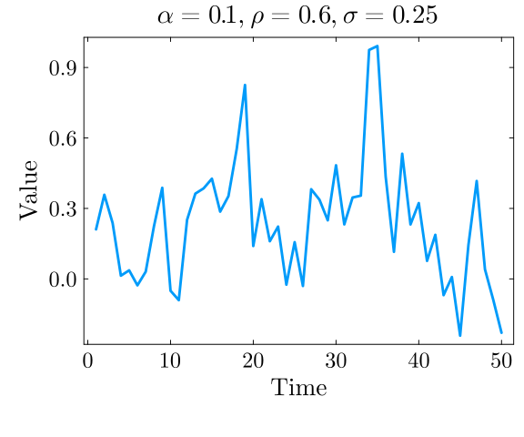

Figure 4: Simulated AR(1) data

```julia
α = 0.1
ρ = 0.6
σ = 0.25
T = 50
ts_sim = zeros(T)
# simulate synthetic AR(1) series
for t = 1:T
    if t == 1
        ts_sim[t] = rand(Normal(0, sqrt(σ^2 / (1 - ρ^2))))
    else
        ts_sim[t] = α + rand(Normal(ρ * ts_sim[t-1], σ))
    end
end

plot(1:T, ts_sim, linewidth=3, xlabel="Time", ylabel="Value", title=L"$α = 0.1, ρ = 0.6, σ = 0.25$")
plot!(size=(600, 500))
```

```julia
lb = [-5.0, -0.99, 0.01]
ub = [5.0, 0.99, 5]
init = [0.0, 0.6, 0.3]

optim_whitened = Optim.optimize(θ -> -ar1_loglik_whitened(θ, ts_sim), lb, ub, init)
θ_wn_mle = round.(optim_whitened.minimizer; digits=2)
@show θ_wn_mle;

optim_joint = Optim.optimize(θ -> -ar1_loglik_joint(θ, ts_sim), lb, ub, init)
θ_joint_mle = round.(optim_joint.minimizer; digits=2)
@show θ_joint_mle;
```

```
θ_wn_mle = [0.12, 0.5, 0.22]
θ_joint_mle = [0.12, 0.5, 0.22]
```

# Dealing with Trends

## AR(1) with Trend

$$y_t = \underbrace{x_t}_{\text{fluctuations}} + \underbrace{z_t}_{\text{trend}}$$

- Model trend with regression:
  $$y_t - (a + bt) \sim N(\rho (y_{t-1} - (a + b(t-1))), \sigma^2)$$
- Model the **spectrum** (frequency domain, for periodic trends).
- Difference values (**integrated** time series model): $\hat{y}_t = y_t - y_{t-1}$

## Spectral Analysis Example

**Spectral analysis**: Based on Fourier decomposition to switch between **time domain** and **frequency domain**.

The resulting important frequencies can be used in a regression
$$y_t = A \cos(\omega t) + B \sin(\omega t) + C + \varepsilon_t$$

where $\varepsilon_t$ has a Gaussian or AR model.

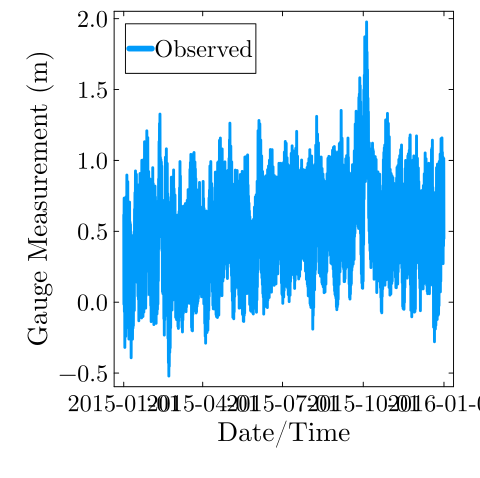

Figure 5: 2015 tide gauge data from the Norfolk, VA tide gauge.

```julia
function load_data(fname)
    date_format = "yyyy-mm-dd HH:MM"
    # this uses the DataFramesMeta package -- it's pretty cool
    return @chain fname begin
        CSV.File(; dateformat=date_format)
        DataFrame
        DataFrames.rename(
            "Time (GMT)" => "time", "Predicted (m)" => "harmonic", "Verified (m)" => "gauge"
        )
        @transform :datetime = (Date.(:Date, "yyyy/mm/dd") + Time.(:time))
        select(:datetime, :gauge, :harmonic)
        @transform :weather = :gauge - :harmonic
        @transform :month = (month.(:datetime))
    end
end

dat = load_data("data/surge/norfolk-hourly-surge-2015.csv")

p1 = plot(dat.datetime, dat.gauge; ylabel="Gauge Measurement (m)", label="Observed", legend=:topleft, xlabel="Date/Time", bottom_margin=5mm, left_margin=5mm, right_margin=5mm, size=(500, 500))
```

## Periodogram: Tide Gauge

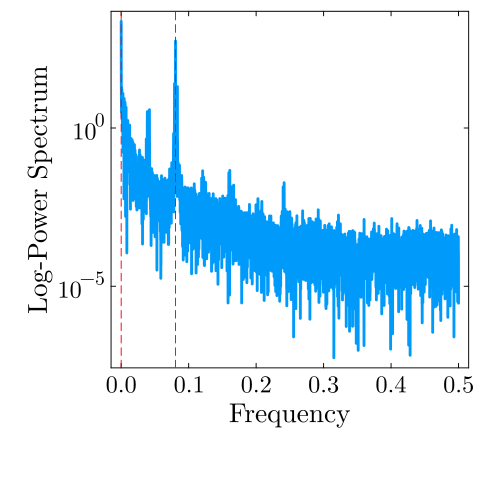

Figure 6: Periodogram for the NOrfolk Tide Gauge Data

```julia
T = nrow(dat) # get number of samples (this is hourly in this case), so 8760
ps = DSP.periodogram(dat.gauge) # compute periodogram with T sampling frequency
plot(ps.freq, ps.power, xlabel="Frequency", ylabel="Log-Power Spectrum", legend=false, linewidth=3, yaxis=:log, size=(500, 500))
vline!([0, .0805], color=:red, linestyle=:dash, lw=1)
```

The biggest spikes are at frequency 0 (no period; this is just a drift without harmonic behavior) and frequency 0.0805.

## Potential Harmonic Model for Tide Gauge Data

So might write a model
$$y_t \sim A + Bt + C\cos(2\pi(.0805)t) + D\sin(2\pi(.0805)t) + \varepsilon_t$$
where $\varepsilon_t$ is a residual process (could be AR(p)).

## General Idea of Workflow

For a given set of parameters:

1. Evaluate trend model to get predictions $S(t)$;
2. Calculate residuals $r(t) = y(t) - S(t)$;
3. Maximize likelihood of residuals according to probability model.

## Warning About Workflow

Should do this all within a single likelihood calculation.

**Do not** estimate trend using a simple regression and then fit the residuals to an AR process.

You could get **very different** parameter estimates.

## Be Cautious with Detrending!

**Dragons**: Extrapolating trends identified using “curve-fitting” is highly fraught, complicating projections.

Better to have an explanatory model and then fit autoregressive models to the residuals…

[figure not shown]

Dog Growth Extrapolation Cartoon

Source: Reddit (original source unclear…)

# Sea-Level Rise Example

## Sea Level Rise Data

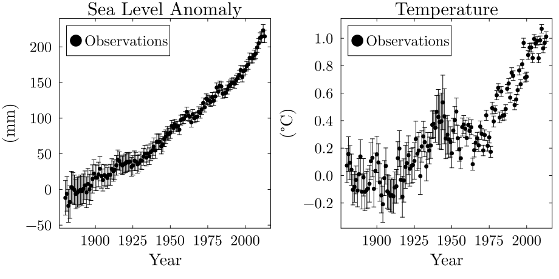

Figure 7: Global mean sea level and temperature data.

## SLR Autocorrelation

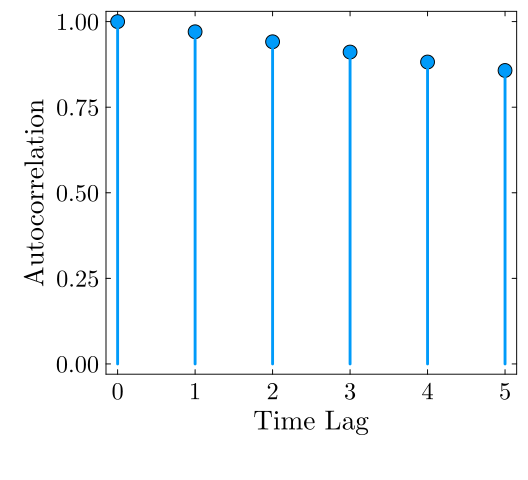

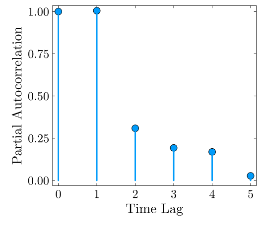

(b)

Figure 8

```julia
pacf_slr = pacf(sl_dat[!, :GMSLR], 0:5)

p1 = plot(0:5, autocor(sl_dat[!, :GMSLR], 0:5), marker=:circle, line=:stem, linewidth=3, markersize=8, legend=false, ylabel="Autocorrelation", xlabel="Time Lag", size=(550, 500))
p2 = plot(0:5, pacf_slr, marker=:circle, line=:stem, markersize=8, linewidth=3, legend=false, ylabel="Partial Autocorrelation", xlabel="Time Lag", size=(550, 500))

display(p1)
display(p2)
```

## SLR Model

Simple model of sea-level rise from Grinsted et al. (2010):

$$\begin{aligned}
\frac{dS}{dt} &= \frac{S_\text{eq} - S}{\tau} \\
S_\text{eq} &= aT + b,
\end{aligned}$$

## Models and Autocorrelation

**Note**: Hypothetically this type of model can capture all of the autocorrelation (or at least non-stationarity) in the data, since:

1. the forcings ($T$) are autocorrelated;
2. the differential equation models $dS/dt$ as a function of $S$.

So a good strategy is to try to calibrate this model without assuming AR(1) residuals, then see if they’re necessary (HW3).

## Model Discretization

Many ways to discretize model, we use the simplest (forward Euler) based on $\frac{dy}{dx} = \lim_{\Delta x \to 0} \frac{y(x + \Delta x) - y(x)}{\Delta x}$:

1. Replace $\frac{dS}{dt}$ with $\frac{S(t + \Delta t)}{\Delta t}$ for some small time step $\Delta t > 0$ (here take $\Delta t = 1$ yr)
2. Solve for $S(t + \Delta t)$.

## Discrete SLR Model

$$\begin{aligned}
\frac{S(t+1) - S(t)}{\Delta t} &= \frac{S_\text{eq}(t) - S(t)}{\tau} \\[0.5em]
S_\text{eq}(t) &= a T(t) + b, \\[1.5em]
\Rightarrow S(t+1) &= S(t) + \Delta t \frac{S_\text{eq}(t) - S(t)}{\tau} \\[0.5em]
S_\text{eq}(t) &= a T(t) + b,
\end{aligned}$$

## From Numerical to Probability Model

We can treat this like any other regression, but use model for $S(t)$ instead of *e.g.* linear model:

**Assuming i.i.d. Gaussian residuals**:
$$y_t = S(t) + \varepsilon_t, \qquad \varepsilon_t \sim N(0, \sigma^2)$$

**If residuals are autocorrelated**:
$$y_t = S(t) + \omega_t, \quad \omega_t = \rho \omega_{t-1} + \varepsilon_t, \quad \varepsilon_t \sim N(0, \sigma^2)$$

# Key Points

## Key Points

- Can do inference for AR(1) either by whitening residuals or fitting joint distribution.
- Often numerical models have autocorrelated residuals: this *can* produce very different estimates than assuming independent Gaussian residuals.
- Common problem when fitting models by minimizing (R)MSE!

## For More On Time Series

**Courses**

- STSCI 4550/5550 (Applied Time Series Analysis),
- CEE 6790 (heavy focus on spectral analysis and signal processing)

**Books**

- Shumway & Stoffer (2025)
- Hyndman & Athanasopoulos (2021)
- Durbin & Koopman (2012)
- Banerjee et al. (2011)
- Cressie & Wikle (2011)

# Upcoming Schedule

## Next Classes

**Next Week**: Extreme Values (Theory and Models)

**Next Unit**: Hypothesis Testing, Model Evaluation, and Comparison

## Assessments

**HW2**: Due Friday at 9pm.

**Exercises** and **Reading** due Monday.

**HW3**: Assigned on Monday, due 3/6.

**Quiz 2**: 3/13.

# References

## References (Scroll For Full List)

Banerjee, S., Carlin, B. P., & Gelfand, A. E. (2011). *Hierarchical modeling and analysis for spatial data, second edition* (2nd ed.). Philadelphia, PA: Chapman & Hall/CRC. https://doi.org/10.1201/b17115

Cressie, N., & Wikle, C. K. (2011). *Statistics for Spatio-Temporal Data*. Hoboken, NJ: Wiley.

Durbin, J., & Koopman, S. J. (2012). *Time series analysis by state space methods* (2nd ed.). London, England: Oxford University Press. https://doi.org/10.1093/acprof:oso/9780199641178.001.0001

Grinsted, A., Moore, J. C., & Jevrejeva, S. (2010). Reconstructing sea level from paleo and projected temperatures 200 to 2100 ad. *Clim. Dyn.*, *34*, 461–472. https://doi.org/10.1007/s00382-008-0507-2

Hyndman, R. J., & Athanasopoulos, G. (2021). *Forecasting: Principles and Practice (3rd ed)*. Melbourne, Australia: OTexts. Retrieved from https://otexts.com/fpp3/

Shumway, R. H., & Stoffer, D. S. (2025). *Time series analysis and its applications*. Springer.